# Lubridate: Working with Dates & Times in R

Malcolm Mashig | Jordan Denish | Kunaal Sarnaik

Due Date: March 4th, 2020

### Lubridate Overview

#### Purpose

Date-time data can be extremely frustrating to work with in R or any coding language/interface. There are many characteristics of date-time data that must be taken into account – including format, timezones, and calendar inconsistencies such as leap years and daylight savings time (DST). Base R commands for date-times are relatively unintuitive and have unpredictable results depending on the type of object being used. The `lubridate` package is the Tidyverse solution to the many problems that arise when working with dates and times that data scientists often encounter. The functions available through `lubridate` allow for simple and straightforward algebraic manipulation of date-time and time-span objects.

The difficulties of working with dates and times:

- The (more than) 38 different time zones
- Leap Days
  - The year must be evenly divisible by 4
  - BUT if the year is evenly divisible by 100, it must also be divisible by 400
  - Therefore, 2100 is **not** a leap year while 2020 and 2400 **are** leap years
- Some minutes have 61 seconds (leap second as the Earth’s rotation is gradually slowing down over time)
- Daylight Savings Times (DST)

*Dates and times must reconcile two physical phenomena (rotation of the Earth and its orbit with the sun) with a whole raft of geopolitical phenomena*

#### Background Information

The three object types dealing with dates and times:

- Date: $<$date$>$ tibble
- Time within a day: $<$time$>$ tibble
- Date-time (date along with a time): $<$dttm$>$ tibble

Three ways likely to create a date/time:

- From a string
  - … that must be parsed into a date-time. `lubridate` automatically works out the format once you specify the order of the components (year, month, day, etc.). It can also handle unquoted numbers.
- From individual date-time components
  - You may have individual components spread across multiple columns in a data set
- From an existing date/time object
  - You may want to switch between a date-time and a date (i.e., conversion)

#### Version History

##### *Version 0.1* came out on August 14th, 2010

- Many base functions including am (boolean to check if a date occurs in am or pm), is.instant (checks if it is a date-time object) and guess_format (character or numeric vector)
- R could now work with complicated features of time such as leap years, daylight savings time, different time zones, military time, and a wide variety of date-time formats.
- Initial versions would overwrite many functions and basic operations from base R (such as “+”, “-”, “start()”, “end”), which made it difficult to use `lubridate` with highly complicated programs
- `lubridate` has since been gradually modified to become more flexible with different kinds of data structures and programs.

##### *Version 1.1.0* came out on March 5th, 2012

- Interval creation function (%-%)
- No longer overwrites base R methods for addition, subtraction, multiplication, division, etc.

##### *Version 1.3.0* came out on September 20th, 2013

- Allowed math used on dates and times to be more consistent in operation
- If adding or subtracting months or days would result in a non-existent date, returns NaN instead of a day in the following month or year (what occurred prior to this udpate)

##### *Version 1.5.0* came out on December 3rd, 2015

- Added a time_length method and time spans were refactored for increased speed of compilation and decreased run time

##### *Version 1.7.2* came out on February 6th, 2018

- Comparability between Duration, Period, and difftime functions
- Updates since *Version 1.7.2* have simply been bug fixes or patches rather than the addition of new functions

##### Current is *Version 1.7.4*, which came out on April 11th, 2018

#### Similar Packages / Usage Dependency

- Part of the tidyverse ecosystem of packages
  - Shares underlying design philosophy, grammar, and data structures with other tidyverse subpackages such as readr, ggplot2, purrr, and tidyr
- Relies on Google’s CCTZ library for the date-time updates and time-zone manipulation (built-in CCTZ package)
  - Civil-time library -> Computing with human-scale time, such as simple dates
  - Time-Zone library -> IANA (Internet Assigned Numbers Authority) time zone database
  - Installed on the system to convert between civil time and absolute time
  - Time Zones are used to convert between absolute time and civil time
- Base R has built in functions that can work with and manipulate dates
  - Base R: as.Date() converts a string to a date, but the string must be in the exact YYYY-MM-DD format or else the conversion will be incorrect.
  - Much less flexible than `lubridate`
  - Can also use the sequence function with dates and times
  - Base R also includes the classes POSIXct and POSIXlt that can do basic operations such as reading in and accessing dates/times:
  - POSIXct works with calendar times
  - POSIXlt works with local times
  - Lubridate has more capabilities to work with date and time complications compared to base R.
- `Chron` Package
  - Creates chronological objects that can handle dates and times
  - Creates vectors with times and dates
  - Can do simple operations such as data/time comparisons and addition/subtraction
  - Can sort by date and time
  - Still cannot handle more complicated features of dates and times such as time zones and projecting future times
- `timelineS` Package
  - Plotting annotated timelines, grouped timelines, and exploratory graphics such as histograms
  - Can filter and summarize date data by duration and convert to calendar units
  - Lubridate does not have any built-in functions that can create visual timelines or graphics that `timelineS` does
    - Instead would have to use `ggplot2` in conjunction in order to do so
  - `timelineS` does NOT provide any functions dealing with time objects or geopolitical complications (DST, time zones, etc.)
    - Still must use lubridate to reconcile these

### Examples of Usage

#### **Easily convert disorganized data entries to dates**

In Base R:

```r
data <- data.frame(
  date = c("2019/05/03",
           "2018/02/8",
           "2016-02/29"), # notice the data entry error
  measure = c(25, 22, 17)
)
data %>%
  mutate(
    date = as.Date(date)
  )
```

| date | measure |
| --- | --- |
| 2019-05-03 | 25 |
| 2018-02-08 | 22 |
| NA | 17 |

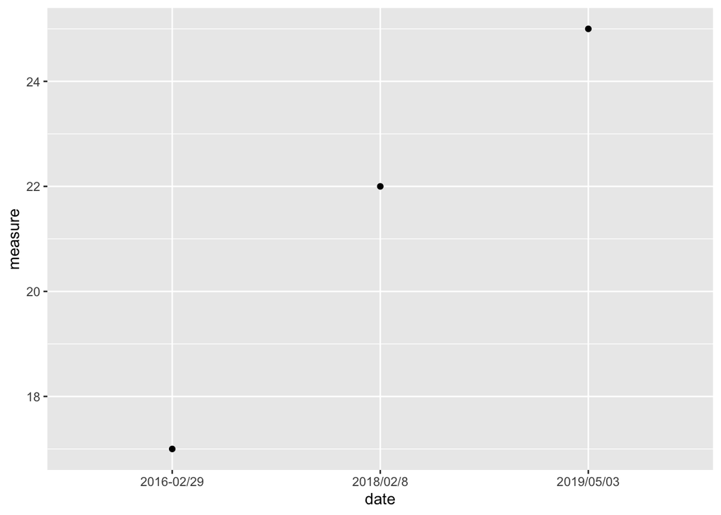

```r
data %>% ## Not what we want
  ggplot() +
  geom_point(aes(date, measure))
```

```r
# An unnecessary step
data$date = gsub(
  x = data$date,
  pattern = "-",
  replacement = "/"
  )

data %>%
  mutate(
    date = as.Date(date)
  )
```

| date | measure |
| --- | --- |
| 2019-05-03 | 25 |
| 2018-02-08 | 22 |
| 2016-02-29 | 17 |

As can be seen with base R in the above chunks, it is necessary to have an additional step to replace the invalid date format with a valid one prior to R recognizing the date. Otherwise, it calls the date NA.

Also notice how the plot above is not really continuous in terms of the time, it is instead discrete in terms of the date. Base R treats the dates as categories rather than along a continuous timeline.

With `lubridate`:

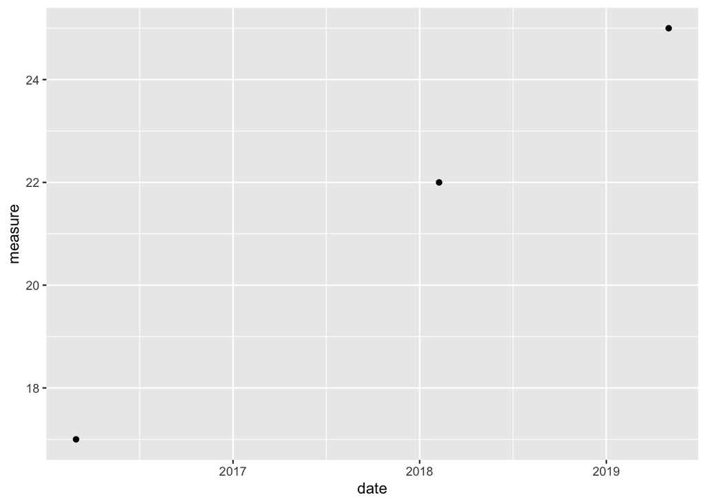

```r
# install.packages('lubridate')
library(lubridate)
lubridata <- data %>%
  mutate(
    date = ymd(date)
  )

lubridata %>% # What we want
  ggplot() +
  geom_point(aes(date, measure))
```

With lubridate, there is no need for the additional replacement step. It immediately recognizes the date with this format. The plot is also now continuous on the x-axis in terms of time.

NOTICE: The smaller size of the code chunk when using lubridate rather than using base R.

#### **Easily separate out date components**

In Base R:

```r
data$month = format(as.Date(data$date), "%m")
data$year = format(as.Date(data$date), "%Y")
data$day = format(as.Date(data$date), "%d")
## character components
```

With `lubridate`:

```r
data %>% # ensures numeric components
  mutate(month = month(date),
         year = year(date),
         day = day(date))
```

| date | measure | month | year | day |
| --- | --- | --- | --- | --- |
| 2019/05/03 | 25 | 5 | 2019 | 3 |
| 2018/02/8 | 22 | 2 | 2018 | 8 |
| 2016/02/29 | 17 | 2 | 2016 | 29 |

#### **Easily manipulates dates**

In Base R:

```r
as.Date(data$date) + 365*4
```

```
## [1] "2023-05-02" "2022-02-07" "2020-02-28"
```

```r
# Lacks intuition and flexibility
```

With `lubridate`:

```r
data %>%
  mutate(
    date = ymd(date) + years(4)
  )
```

| date | measure | month | year | day |
| --- | --- | --- | --- | --- |
| 2023-05-03 | 25 | 05 | 2019 | 03 |
| 2022-02-08 | 22 | 02 | 2018 | 08 |
| 2020-02-29 | 17 | 02 | 2016 | 29 |

```r
## last date is leap year day
## works the same for months, days, minutes, etc.
```

#### **Easily determine duration**

In Base R:

```r
difftime(
  data$date[1],
  data$date[2],
  )
```

```
## Time difference of 448.9583 days
```

```r
## does not work with years or months
difftime(
  data$date[1],
  data$date[2],
  unit = "years"
  )
```

```
## Error in match.arg(units): 'arg' should be one of "auto", "secs", "mins", "hours", "days", "weeks"
```

With `lubridate`:

```r
# Safe - should return error
time_length(
  data$date[1] - data$date[2],
  unit = "days")
```

```
## Error in data$date[1] - data$date[2]: non-numeric argument to binary operator
```

```r
time_length(
  ymd(data$date[1]) - ymd(data$date[2]),
  unit = "years")
```

```
## [1] 1.230137
```

As can be seen above, ymd function in lubridate can easily determine duration without throwing an error between years.

#### **Other useful functions**

```r
#Adding a time zone label to the date
# UTC is the universal time zone label
mdy("January 31st, 2017", tz = "UTC")
```

```
## [1] "2017-01-31 UTC"
```

```r
#Adds the hours, minutes, and seconds to the date for a date-time object
mdy_hms("January 31st, 2020 11, 02, 01")
```

```
## [1] "2020-01-31 11:02:01 UTC"
```

```r
#Returns the number of seconds and amount of weeks for 15 days
ddays(15)
```

```
## [1] "1296000s (~2.14 weeks)"
```

```r
#Adds a time zone argument to the date-time object. Can place the location of the time zone and it will automatically replace with the name of the time zone (EDT)
ymd_hms("2015-06-01 12:00:00", tz = "America/New_York")
```

```
## [1] "2015-06-01 12:00:00 EDT"
```

```r
#You can change the month of a date object if needed
x <- ymd("2019-02-18")
month(x) = 3
x
```

```
## [1] "2019-03-18"
```

```r
#Method floor_date changes the date to the nearest boundary of the given unit argument.
#In this case, changes the day to the first as the unit argument was month.
floor_date(x, unit = "month")
```

```
## [1] "2019-03-01"
```

```r
#Returns the weekday the given date was on
wday(x, label = TRUE, abbr = FALSE)
```

```
## [1] Monday
## 7 Levels: Sunday < Monday < Tuesday < Wednesday < Thursday < ... < Saturday
```

### Reflection

#### Advantages

- Efficiently tracks date and time data while taking into account all of the previously mentioned difficulties associated with it
- Huge advancement on base R dealing with dates and times
  - Works with complicated geopolitical ideas of leap years, daylight savings, and different time zones.
- Can make sorting between dates and times of data structures very easy
  - Saves a lot of hassle and not as much worry about geopolitical phenomena (lubridate automatically accounts for it)
- Functions are well named and it is easy to identify what each one does
  - ymd() parses into YYYY-MM-DD while ydm() parses into YYYY-DD-MM
- Subpackage within tidyverse allows consistency between other packages and combined usage for complex goals.
  - Ggplot2, tidyr, purrr, etc.

#### Disadvantages

- Dependency on the CCTZ package
  - The ymd family of functions directly drop to the internal C parser for numeric months, but use R’s strptime() for alphabetic months.
  - Therefore, some of strptime()’s limitations are inherited by lubridate’s parser.
  - Ex. Truncated formats (%Y-%b) will not be parsed while numeric truncated formats (%Y-%m) are handled correctly by lubridate’s C parser.
  - If CCTZ is down or problematic lubridate could be affected
- R does not come with predefined time zone names, so it depends on the user’s operating system for time zone name
- Can be different with use of different computers and operating systems (Mac versus PC versus Linux).
- Does not take into account holidays (Labor Day, Thanksgiving, etc.). Does not recognize Thanksgiving is the third Thursday of November
- Could be faster, as always
- Last version was released in April 2018
  - Has not been updated in almost two years
  - Pending release has identified many compilation bugs that producers are currently fixing
- Some locales that use DST on paper have populations within that may not actually practice it
  - Arizona contains a high percentage of people that do not follow DST

#### Suggestions for Future Additions/Improvements

- **Universal method** to parse automatically the day, month, year, and time of an input if it is in a compatible format
  - If the day is greater than 12, lubridate could recognize that it can’t be a valid month and use the potential universal function
  - Limitation of this is that some day values (i.e., day $<$ 12) can also be possible month values
- Calendar data structure or methods for scheduling, reminders, etc. that can be uploaded to the user’s console
- Utilize a function that takes EXIF data input from photos to parse their date and time
  - Can see when a photo was taken if one wanted to sort chronologically among their photo library
  - If you get a random photo from google, maybe parse the date-time object of access, production, upload, etc.
- Be able to work with different calendars in other parts of the world (Chinese Calendar, Mayan Calendar, etc.)
- Taking into account holidays for data sets on jobs, activity, etc.
- Function to return the Carbon-12 to Carbon-14 isotope proportion or tree ring number of a past date
- Could be useful in STEM/Archaeology fields
- Conversion to time durations on other planets or areas in the universe for GIS or aerospatial data sets